# Plant Trait Harvest — Detailed Cross-Provider Report

## 4 Trait Coverage - Detailed

### 4.1 Top 25 traits combined

Top 25 traits by row count (all providers combined)

| Trait Name | Rows | Distinct Taxa |
| --- | --- | --- |
| plant_growth_form | 112,992 | 31,557 |
| plant_height | 112,521 | 35,719 |
| stomatal_conductance | 101,312 | 49,329 |
| life_history | 86,663 | 30,341 |
| leaf_length | 82,565 | 21,156 |
| woodiness_detailed | 78,376 | 30,563 |
| leaf_width | 74,333 | 19,910 |
| specific_leaf_area | 64,588 | 14,584 |
| fruit_type | 57,348 | 25,328 |
| leaf_dry_matter_content | 49,402 | 2,183 |
| growth_form | 41,949 | 13,850 |
| fruit_dehiscence | 41,701 | 24,251 |
| seed_dry_mass | 40,423 | 9,971 |
| fruit_length | 39,345 | 13,142 |
| plant_photosynthetic_organ | 36,845 | 20,543 |
| resprouting_capacity | 35,395 | 13,785 |
| flowering_time | 33,822 | 18,808 |
| leaf_mass_per_area | 32,937 | 4,089 |
| fruit_fleshiness | 32,610 | 21,402 |
| leaf_area | 31,931 | 6,885 |
| leaf_compoundness | 31,594 | 18,947 |
| root_tissue_density | 30,550 | 49 |
| leaf_shape | 29,291 | 17,591 |
| seed_length | 29,285 | 9,916 |
| sex_type | 27,014 | 21,687 |

### 4.2 Top 20 traits - provider contribution

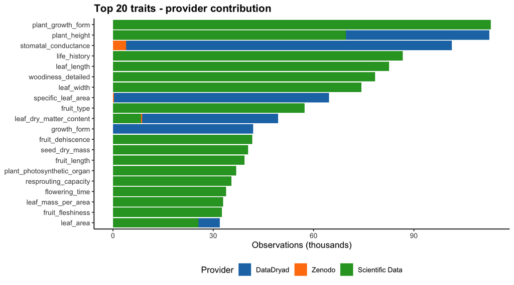

### 4.4 Trait value summary statistics (top 20 numeric traits)

Summary statistics for top 20 numeric traits (rows with finite numeric trait_value only)

| Trait Name | n | Mean | Median | SD | Min | P5 | P25 | P75 | P95 | Max |
| --- | --- | --- | --- | --- | --- | --- | --- | --- | --- | --- |
| plant_height | 100,720 | 23.5113 | 1.5000 | 114.1298 | -4.6052 | 0.1000 | 0.4275 | 12.0000 | 80.0000 | 4,000.000 |
| leaf_length | 82,565 | 99.3894 | 46.0000 | 554.1618 | 0.1000 | 4.0000 | 15.0000 | 100.0000 | 300.0000 | 100,000.000 |
| leaf_width | 74,333 | 19.2259 | 8.0000 | 80.4010 | 0.0400 | 0.8000 | 2.3000 | 20.0000 | 70.0000 | 14,000.000 |
| specific_leaf_area | 49,564 | 1,964.1797 | 24.4000 | 11,338.2280 | -2.5349 | 11.3802 | 17.8700 | 108.2165 | 10,480.8705 | 384,854.130 |
| leaf_dry_matter_content | 45,283 | 180.3589 | 192.8000 | 158.5415 | -2.8518 | 0.2055 | 0.4870 | 307.2000 | 452.3000 | 693.069 |
| seed_dry_mass | 40,423 | 106.1336 | 2.0592 | 4,478.5738 | 0.0001 | 0.0476 | 0.4248 | 10.3000 | 55.7000 | 617,000.000 |
| fruit_length | 39,345 | 20.3785 | 8.0000 | 41.7285 | 0.1000 | 1.2000 | 3.5000 | 20.0000 | 85.0000 | 2,000.000 |
| leaf_mass_per_area | 32,937 | 168.2304 | 139.2200 | 140.3025 | 1.7218 | 23.2603 | 75.1880 | 225.6380 | 393.8681 | 2,772.988 |
| leaf_area | 31,740 | 2,316.2801 | 679.6250 | 18,445.0702 | -1.5233 | 2.8233 | 56.3832 | 2,228.0000 | 8,160.0000 | 2,118,974.000 |
| seed_length | 29,285 | 6.2080 | 4.0000 | 10.7223 | 0.0100 | 0.8000 | 2.0000 | 6.0000 | 20.0000 | 650.000 |
| fruit_width | 26,314 | 10.6275 | 7.0000 | 14.6300 | 0.1000 | 1.0000 | 4.0000 | 12.0000 | 31.0000 | 550.000 |
| Plant height, vegetative | 25,453 | 0.2101 | 0.0860 | 0.3752 | 0.0006 | 0.0190 | 0.0500 | 0.2000 | 0.8600 | 5.500 |
| root_tissue_density | 22,105 | 8.7085 | 0.0660 | 74.2838 | 0.0070 | 0.0340 | 0.0500 | 0.0930 | 0.2200 | 2,734.570 |
| wood_density | 20,899 | 0.5736 | 0.5510 | 0.1469 | 0.0571 | 0.3700 | 0.4810 | 0.6700 | 0.8390 | 1.920 |
| petiole_length | 15,515 | 3.6506 | 1.0000 | 13.7138 | 0.0000 | 0.0700 | 0.4000 | 2.5000 | 12.0000 | 400.000 |
| leaf_dry_mass | 15,427 | 289.8446 | 178.0000 | 426.4185 | 0.1000 | 2.0000 | 42.7500 | 391.0000 | 923.9600 | 10,538.000 |
| seed_width | 15,106 | 4.2898 | 2.6800 | 5.8358 | 0.0100 | 0.5000 | 1.5000 | 4.5000 | 15.0000 | 100.000 |
| Leaf area per leaf dry mass (specific leaf area, SLA) | 12,078 | 14.5619 | 12.9188 | 8.3772 | 0.1180 | 4.6430 | 9.0332 | 18.2392 | 29.9717 | 84.000 |
| leaf_N_per_dry_mass | 11,638 | 15.0960 | 13.2000 | 7.6424 | 0.6734 | 6.1808 | 9.9702 | 18.3067 | 30.0000 | 75.000 |
| Leaf area | 11,498 | 696.3869 | 163.0000 | 4,048.2191 | 0.2509 | 6.9352 | 49.9883 | 443.6027 | 2,427.4865 | 162,259.590 |

### 4.5 Trait value boxplots (top 12 numeric traits)

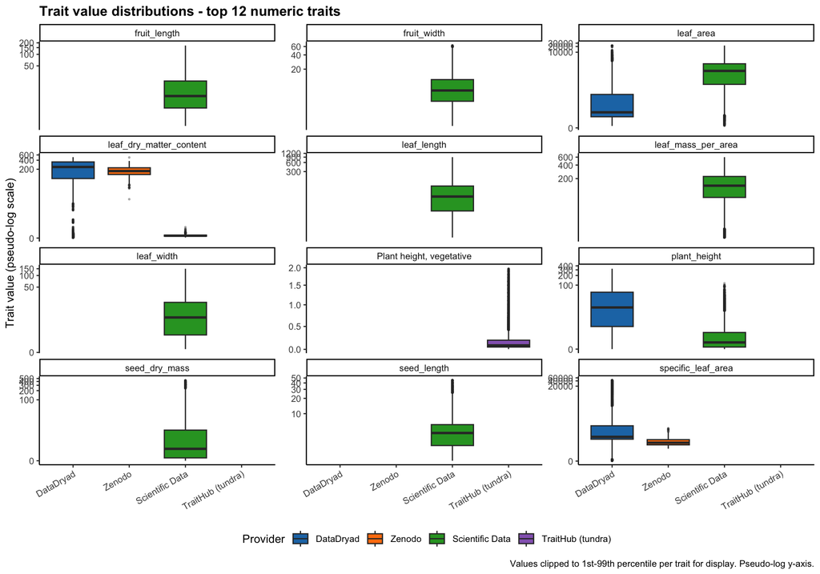

## 5 Taxonomic Coverage

### 5.1 Top 25 taxa by row count

Top 25 taxa by row count (all providers)

| Species (scrubbed) | Rows | Distinct Traits |
| --- | --- | --- |
| Wahlenbergia ceracea | 11,334 | 87 |
| Epigeo rhizomes | 4,257 | 3 |
| Corymbia calophylla | 4,086 | 88 |
| Vaccinium vitis-idaea | 4,036 | 23 |
| Hypogeo rhizomes | 3,807 | 3 |
| Empetrum nigrum | 3,712 | 24 |
| Eucalyptus tereticornis | 3,012 | 120 |
| Betula nana | 2,762 | 23 |
| Oreomyrrhis eriopoda | 2,547 | 94 |
| Aciphylla glacialis | 2,380 | 97 |
| Callitris rhomboidea | 2,357 | 77 |
| Salix arctica | 2,351 | 19 |
| Vaccinium uliginosum | 2,314 | 25 |
| Eucalyptus sideroxylon | 2,254 | 116 |
| Betula glandulosa | 2,192 | 16 |
| Eucalyptus pauciflora subsp. niphophila | 2,189 | 69 |
| Wollemia nobilis | 1,967 | 56 |
| Corymbia gummifera | 1,952 | 226 |
| Vaccinium myrtillus | 1,907 | 21 |
| Eucalyptus tetrodonta | 1,880 | 135 |
| Eucalyptus obliqua | 1,872 | 162 |
| Nonclonal perennial | 1,863 | 3 |
| Eucalyptus pauciflora subsp. pauciflora | 1,851 | 69 |
| Eucalyptus crebra | 1,844 | 134 |
| Acacia hakeoides | 1,603 | 82 |

### 5.2 Distinct taxa per provider

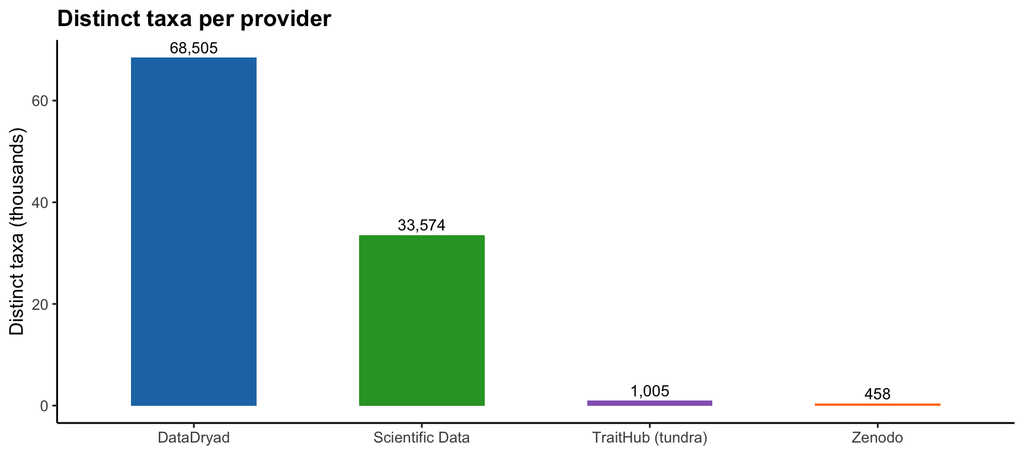

### 5.3 Country breakdown (top 20)

[figure not shown]

### 5.4 Date collected - year distribution

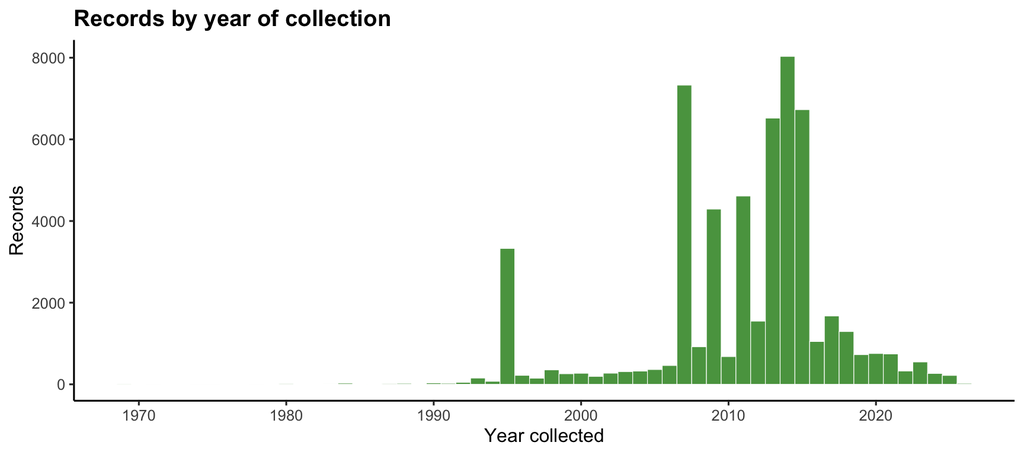

## 6 Unit Reconciliation Summary

6.1 Unit inference summary by provider

| Provider | Total Rows | Inferred TRUE | Inferred FALSE | Conf: high | Conf: medium | Conf: low | Conf: none/missing |
| --- | --- | --- | --- | --- | --- | --- | --- |
| DataDryad | 414,226 | 401,492 | 12,248 | 241,648 | 107,578 | 5,160 | 0 |
| Zenodo | 4,630 | 4,630 | 0 | 4,290 | 340 | 0 | 0 |
| Scientific Data | 1,810,852 | 0 | 0 | 110,803 | 29,846 | 0 | 0 |
| TraitHub (tundra) | 91,970 | 0 | 0 | 0 | 0 | 0 | 0 |

### 6.2 inferred_unit_confidence breakdown

inferred_unit_confidence counts by provider (wide)

| inferred_unit_confidence | DataDryad | Scientific Data | TraitHub (tundra) | Zenodo |
| --- | --- | --- | --- | --- |
| high | 241,648 | 110,803 | 0 | 4,290 |
| low | 5,160 | 0 | 0 | 0 |
| medium | 107,578 | 29,846 | 0 | 340 |
| none | 59,840 | 1,670,203 | 91,970 | 0 |

### 6.3 basis_type breakdown

basis_type counts by provider (wide)

| basis_type | DataDryad | Scientific Data | TraitHub (tundra) | Zenodo |
| --- | --- | --- | --- | --- |
| (empty) | 409,066 | 1,810,852 | 91,970 | 4,630 |
| unknown | 5,160 | 0 | 0 | 0 |

### 6.4 Note on AusTraits / Scientific Data unit confidence

**Pipeline labeling note - Scientific Data “none” unit confidence:** Scientific Data rows show `inferred_unit_confidence = “none”` because the simple-schema mapper used for this provider did not populate the `basis_type` or `value_type` metadata columns that the confidence scorer uses as inputs. AusTraits (the dominant Scientific Data source) is a fully curated, peer-reviewed database (Falster et al. 2021, doi:10.1038/s41597-021-01006-6). Its units were set by the original data contributors and validated during publication. The **“none” label reflects a pipeline labeling gap, not a unit quality failure.**

## 7 Geographic Coverage - Interactive Map

7.1 Geographic coordinate coverage by provider

| Provider | Total Rows | Rows with Coords | Coverage (%) |
| --- | --- | --- | --- |
| DataDryad | 414,226 | 51,392 | 12.4 |
| Zenodo | 4,630 | 680 | 14.7 |
| Scientific Data | 1,810,852 | 0 | 0.0 |
| TraitHub (tundra) | 91,970 | 91,827 | 99.8 |

### 7.2 Interactive map (sampled)

```
## > **Map note:** Displaying a random sample of up to 10,000 trait records per provider. Total georeferenced records: 143,899 | Plotted points: 20,680
```

[interactive chart not shown]

### 7.3 Elevation distribution

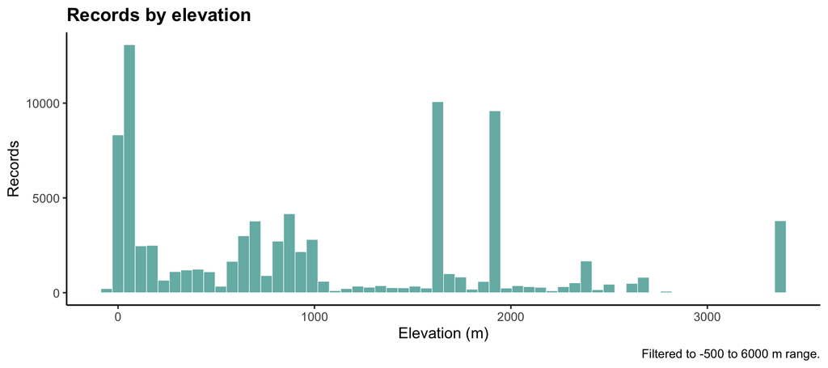

## 8 BIEN Database Mapping Status

### 8.1-8.2 BIEN-mappable rows per provider

8.2 BIEN-mappable rows by trait and provider (exact canonical match)

| BIEN Trait | DataDryad | TraitHub (tundra) | Total |
| --- | --- | --- | --- |
| leaf area | 0 | 11,498 | 11,498 |
| leaf dry mass | 0 | 8,489 | 8,489 |
| leaf nitrogen content per leaf dry mass | 78 | 0 | 78 |
| leaf carbon content per leaf dry mass | 69 | 0 | 69 |

### 8.3 BIEN-mappable rows by provider

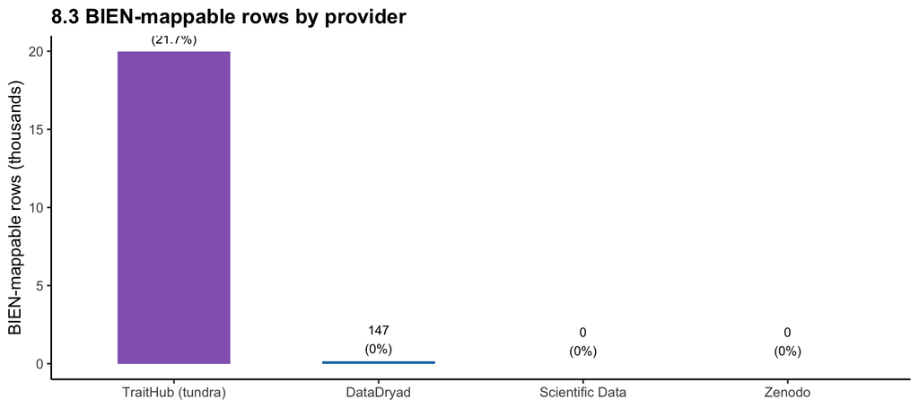

### 8.4 Percentage of rows that are BIEN-mappable

8.4 BIEN-mappable percentage by provider

| Provider | Total Rows | BIEN-Mappable Rows | % Mappable |
| --- | --- | --- | --- |
| DataDryad | 414,226 | 147 | 0.0 |
| Zenodo | 4,630 | 0 | 0.0 |
| Scientific Data | 1,810,852 | 0 | 0.0 |
| TraitHub (tundra) | 91,970 | 19,987 | 21.7 |

> **8.5 Coverage note:** Traits not yet in this lookup are not necessarily unmappable - they may require fuzzy matching or manual review. This table represents **exact canonical name matches only** (case-insensitive, whitespace-trimmed). Full BIEN trait vocabulary integration is a planned pipeline milestone.

## 9 QA Flag Summary

9.1 QA flag prevalence by provider

| Provider | Total Rows | Flagged Rows | Unflagged Rows | Flag Rate (%) |
| --- | --- | --- | --- | --- |
| DataDryad | 414,226 | 372,228 | 41,998 | 89.9 |
| Zenodo | 4,630 | 4,630 | 0 | 100.0 |
| Scientific Data | 1,810,852 | 1,810,852 | 0 | 100.0 |
| TraitHub (tundra) | 91,970 | 47,729 | 44,241 | 51.9 |

### 9.2 DataDryad top 15 QA flag codes

[output not shown]

[output cut: 5 more lines]

### 9.3 Top 15 QA flag codes - bar chart

[figure not shown]

## 10 Pending Sources — Manual Intake Queue

These user-supplied sources are tracked in `data/manual_source_intake.csv` for review, ingestion, and follow-up against the occurrence harvest outputs.

| display_name | source_group | canonical_url_or_doi | related_publication | harvest_status | next_action |
| --- | --- | --- | --- | --- | --- |
| ShrubHub TraitHub GitHub repository | github_repository_with_paper | https://github.com/ShrubHub/TraitHub | Bjorkman et al. 2018, Nature, doi:10.1038/s41586-018-0563-7 — Plant functional trait change across a warming tundra biome | pending_review | Review repository structure and identify ingestible trait tables or exports |
| alltraits with phynames.csv | csv_file |  | Likely Spasojevic et al. 2016, J. Ecology, doi:10.1111/1365-2745.12518 — When does intraspecific trait variation contribute to functional beta-diversity? (to be confirmed against file contents) | pending_review | Inspect file contents and determine whether alltraits and phynames.csv should be ingested separately |
| oztrait data JoE.csv | csv_file | https://doi.org/10.1111/1365-2745.12518 | Spasojevic et al. 2016, J. Ecology, doi:10.1111/1365-2745.12518 — When does intraspecific trait variation contribute to functional beta-diversity? (oztrait = Ozark trait; JoE = Journal of Ecology) | pending_review | Review file contents and compare against existing Ozark or OzTrait-related candidates |
| ozark trait metadata2.xlsx | xlsx_file |  | Companion metadata workbook for Spasojevic et al. 2016 Ozark trait study (doi:10.1111/1365-2745.12518); supplied directly by Jesse Miller. | pending_review | Review workbook sheets and relate them to any distinct manual-source ingest path |
| Re_ Data for BIEN.eml | eml_file |  | Email communication from Jesse Miller (data contact for Ozark Spasojevic 2016 study, doi:10.1111/1365-2745.12518) | pending_review | Inspect metadata and locate any associated data payload before ingest decisions |
| Biodiversity and Ecological long-term plots in Southern Patagonia (BEPSP)_Complete_(Pablo Peri).xlsx | xlsx_from_paper_authors | https://doi.org/10.1016/j.jnc.2016.09.003 | Peri et al. 2016, J. Nature Conservation, doi:10.1016/j.jnc.2016.09.003 — Biodiversity and ecological long-term plots in Southern Patagonia to support sustainable land management: The case of PEBANPA … | pending_review | Review workbook structure and map candidate trait and provenance fields |
| Rasgos-CL — Chilean plant trait database (Dylan Craven) | trait_database | https://bibliotecadigital.infor.cl/handle/20.500.12220/32648 | Craven D. and collaborators — Rasgos-CL Chilean plant trait database. Hosted at INFOR digital library handle 20.500.12220/32648. | pending_review | Download Rasgos-CL trait dataset from INFOR handle; map traits to BIEN trait schema with provenance. |

The manual intake registry currently tracks 7 sources across 1 harvest statuses: 7 `pending_review`.

### 10.1 Compiled manual occurrence sources

The occurrence harvest currently includes 0 compiled manual sources totaling 0 occurrence records, of which 0 have valid geographic coordinates.

The pipeline currently detects 13 compiled_occurrences.csv outputs on disk, but only the 0 sources with harvest_status = ‘compiled’ and >0 occurrence rows are counted in the compiled manual-source totals above.

```
## No compiled manual occurrence sources were detected under output/providers/occurrences.
```

### 10.2 Sources still to ingest

Manual intake sources still to ingest

| source_id | display_name | source_group | harvest_status | canonical_url_or_doi | next_action |
| --- | --- | --- | --- | --- | --- |
| manual_alltraits_phynames_csv | alltraits with phynames.csv | csv_file | pending_review |  | Inspect file contents and determine whether alltraits and phynames.csv should be ingested separately |
| manual_bepsp_pablo_peri_xlsx | Biodiversity and Ecological long-term plots in Southern Patagonia (BEPSP)*Complete*(Pablo Peri).xlsx | xlsx_from_paper_authors | pending_review | https://doi.org/10.1016/j.jnc.2016.09.003 | Review workbook structure and map candidate trait and provenance fields |
| manual_ozark_trait_metadata2_xlsx | ozark trait metadata2.xlsx | xlsx_file | pending_review |  | Review workbook sheets and relate them to any distinct manual-source ingest path |
| manual_oztrait_data_joe_csv | oztrait data JoE.csv | csv_file | pending_review | https://doi.org/10.1111/1365-2745.12518 | Review file contents and compare against existing Ozark or OzTrait-related candidates |
| manual_rasgos_cl_chile_traits | Rasgos-CL — Chilean plant trait database (Dylan Craven) | trait_database | pending_review | https://bibliotecadigital.infor.cl/handle/20.500.12220/32648 | Download Rasgos-CL trait dataset from INFOR handle; map traits to BIEN trait schema with provenance. |
| manual_re_data_for_bien_eml | Re_ Data for BIEN.eml | eml_file | pending_review |  | Inspect metadata and locate any associated data payload before ingest decisions |
| manual_shrubhub_traithub_repo | ShrubHub TraitHub GitHub repository | github_repository_with_paper | pending_review | https://github.com/ShrubHub/TraitHub | Review repository structure and identify ingestible trait tables or exports |

7 manual-intake sources still need ingestion based on the current registry rows where `harvest_status != "compiled"`.

Of those remaining sources, 0 are `pending_manual_access` and 7 are `pending_review`.